# Open Data

- Perché parliamo di dati?
- Perché parliamo di "open"?

## Una volta i dati erano

- Elenchi:
  - Liste
  - Vocabolari
  - Enciclopedie
- Numeri
- Mappe

[figure not shown]

Da una lapide in S. Pietro a Roma

[figure not shown]

## Dopo l'avvento del **digitale** tutto è un dato

- Elenchi
- Numeri
- Testi (la Bibbia è un libro o un testo?)
- Musica
- Immagini
- Telefonate
- ...

## Se è un dato, lo possiamo

- Memorizzare
- Analizzare
- Confrontare
- Utilizzare

[figure not shown]

Fonte: Ericcson

[figure not shown]

## Dati testuali

- Contengono testi, normalmente in "linguaggio naturale".
- Se non sono direttamente narrazioni o descrizioni, sono complicati da gestire automaticamente
- Per questo normalmente vengono *aumentati* con l'introduzione di *markup* o *tag* (il più famoso è l'*hashtag*)

## Dati numerici

- Contengono numeri, interi o con la virgola
- Di solito descrivono una grandezza
- Unità di misura?
- Base?
- Importante sapere quali separatori per i decimali e le migliaia
- Sono "facili" da gestire automaticamente
- Per questo spesso si cerca di ridurre tutto a un numero

## Dati tabulari

- Composti da tabelle di righe e colonne
- Le colonne identificano gli attributi
- Le righe identificano entità
- Per identificare relazioni:
  - sono necessarie più tabelle
  - O più ripetizioni
- Sono "facili" da gestire automaticamente
- I DataBase storicamente sono formati da tabelle (Entity-Relationship)
- Le colonne sono un primo livello informativo
- Tutte le entità devono avere lo stesso numero di attributi

## Dati a oggetti gerarchici

- Composti da oggetti o liste di oggetti che contengono ciascuno
  - attributi
  - altri oggetti o liste di oggetti
- Permettono di gestire relazioni (es. appartenenza) in modo più evidente
- Sono gestibili automaticamente
- La loro gestione è meno efficiente dal punto di vista computazionale
- Ogni entità può avere un numero di attributi diverso

## Dati geografici

- Composti da entità che abbiano associate delle *coordinate*
- Utilizzati nei GIS Geographical Information Systems
- Problema dei sistemi di riferimento e delle proiezioni
  - http://spatialreference.org/
  - https://courses.washington.edu/gis250/lessons/projection/
  - http://epsg.io/?q=Italy
- Normalmente sono coordinate
  - Geografiche, in gradi es [EPSG4326](https://epsg.io/4326)/WGS84 (GPS, Google Earth, ...)
  - Geometriche, in metri es [EPSG3857](https://epsg.io/3857) o [EPSG3003](https://epsg.io/3003) (Monte Mario)

Un tool: QGIS https://www.qgis.org

## *Open* data

- Cos'è il copyright?
  - Quali sono le norme nel nostro paese?
  - Cosa coprono?
- Come si applica il copyright quando il bene è **duplicabile senza danno**?

## Partiamo dal *software*

- Inizialmente il software era tutto libero
- Uno dei primi a farne un problema è stato Henry William "Bill" Gates
- Uno dei primi a contestare questa cosa è stato RMS o Richard Matthew Stallman

[figure not shown]

> The feedback we have gotten from the hundreds of people who say they are using BASIC has all been positive. Two surprising things are apparent, however, 1) Most of these "users" never bought BASIC (less than 10% of all Altair owners have bought BASIC), and 2) The amount of royalties we have received from sales to hobbyists makes the time spent on Altair BASIC worth less than $2 an hour.

> Why is this? As the majority of hobbyists must be aware, most of you steal your software. Hardware must be paid >for, but software is something to share. Who cares if the people who worked on it get paid?

> Is this fair? One thing you don't do by stealing software is get back at MITS for some problem you may have had.

> Bill Gates  
> General Partner, Micro-Soft

## Questione di *licenze*

- Un bene immateriale non lo possiedi, ti viene *dato in licenza*
- La licenza indica quello che ti è permesso e quello che ti è vietato
- In particolare, tutte le licenze ti vietano di
  - Duplicare (tranne che per conservazione)
  - Prestare
  - ...

## Copy*right* e Copy*left*

## Le licenze *Open Source*

- La GPL

Ma anche...

- La MIT
- La Apache
- La freemium
- La shareware
- La freeware
- La public domain
- La WTFPL

## Quali licenze sono considerate *Open Source*?

- Ci aiuta la **OSI Open Source Initiative** https://opensource.org/licenses
- Ci permette anche di **scegliere una licenza** https://choosealicense.com/

### Cos'è una *licenza virale*?

## Come si applica tutto questo ai **dati**?

- I dati sono *software*, ma di un tipo particolare
- Oppure potremmo dire che il software è un dato di tipo particolare

> The **Open Definition** states: "A piece of content or data is open if anyone is free to use, reuse, and redistribute it — subject only, at most, to the requirement to attribute and share-alike."

## Esistono *licenze per i dati*

- Fra le più famose la **Creative Commons** (CC)
- Ma anche qui ci aiuta la **OKFN Open Knowledge Foundation** https://licenses.opendefinition.org/
- Esiste un **selezionatore di licenze** https://creativecommons.org/choose/?lang=it
- Esiste un **motore di ricerca di contenuti open** https://search.creativecommons.org/
- In Italia esiste la **IODL Italian Open-Data License** https://www.dati.gov.it/content/italian-open-data-license-v20

## La *qualità* dei dati

Tim Berners-Lee, l'inventore del World Wide Web, ha definito una classifica dei tipi di Open Data https://www.w3.org/DesignIssues/LinkedData.html basandosi su 5 criteri:

1. **OL** Open License
2. **RE** machine REadable
3. **OF** Open Format
4. **URI** Uniform Resource Identifier
5. **LD** Linked Data

[figure not shown]

# Formati e metadati

## Un formato è un *contratto*

- Comunicazione: trasmittente, ricevente, messaggio
- Perché la comunicazione avvenga correttamente, il messaggio dev'essere compreso
- Il *formato* definisce che aspetto avrà il messaggio, in modo da poterlo decodificare
  - Nella lingua parlata la Lingua è un formato
  - Nella lingua scritta l'alfabeto è un formato
  - I formati digitali puntano alla *non ambiguità*

## I *metadati* sono dati ulteriori che "aumentano" i dati

- Non sono parte del messaggio in sé
- Ma ne aiutano:
  - La comprensione
  - La catalogazione
  - I collegamenti
- Le note di un libro sono metadati
- NB anche i metadati sono dati. E hanno un formato...

### I formati *non readable*

- Raster
- PDF (soprattutto raster)
- In generale i **formati proprietari**

[figure not shown]

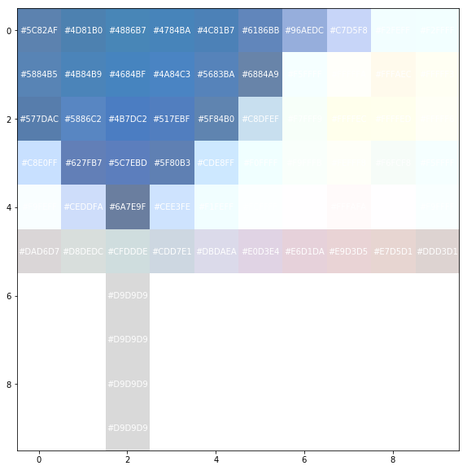

```python
fig
```

## PDF *non* è un formato readable

- https://webproto.si.unimib.it/ADP/

[figure not shown]

### I formati *readable*

Più o meno *strutturati*...

- TXT
- Formati **binari**
  - hanno più problemi dovuti per esempio all'*endianness*
  - sono molto più compatti
  - richiedono una macchina per essere interpretati da un umano
- Formati **human readable**
  - possono essere interpretati (con diversa difficoltà) da un umano
  - sono meno compatti
  - nella pratica, con la compressione il problema dello spazio è molto gestibile

## Esempi di formati *human readable*

- CSV
- XML
- JSON e GeoJSON
- Frictionless datapackage di OKFN
- LOD:
  - JSON-LD
  - RDG
- PDF e OCR e Tabula

## TXT

- Il formato di testo è machine readable, ma in generale *non strutturato*.
- Non è necessariamente una cosa negativa: dipende da cosa rappresenta
- Restano alcuni problemi, legati soprattutto:
  - A come si va "a capo"
  - A come si codificano i caratteri, vedi:
    - https://www.asciitable.com/
    - http://www.unicode.org/
    - https://www.w3schools.com/charsets/ref_html_utf8.asp

## CSV (Comma) Separated Values

- Formato **testuale**
- Formato **tabulare**
- Il separatore può essere la virgola, ma spesso è usato il punto e virgola, la barra verticale, ...
- Alcuni problemi del TXT restano
- Il separatore può confondersi con il separatore dei decimali
- Non è indicato il **tipo delle colonne**
- Non si possono gestire gerarchie
- Parametri importanti:
  - Separatore
  - Carattere che circonda le celle di testo (potrebbero contenere il separatore)
  - (eventuali) linee di Header

## Andiamo a vedere un CSV

https://www.dati.lombardia.it/Solidariet-/Albo-Cooperative-Sociali-al-31-12-2015/tuar-wxya/data

```python
coopSocialiF=open('download/Albo_Cooperative_Sociali_al_31.12.2015.csv','r')

for i in range(4):
    print (coopSocialiF.readline())
```

```
DENOMINAZIONE,COMUNE,PROVINCIA,TELEFONO,EMAIL,AREA,SERVIZI,ATTIVITA,TIPOLOGIE PERSONE SVANTAGGIATE,WGS84_Y,WGS84_X,location

ZEROGRAFICA SOCIETA' COOPERATIVA SOCIALE,Milano,MI,3387621099,,,,Tipografia e stampa,Detenuti,45.5253903,9.0936669,"(45.5253903, 9.0936669)"

STELLA MARIS - SOCIETA' COOPERATIVA SOCIALE ONLUS,Mantova,MN,0376151018,info@coopstellamaris.it,"Anziani, Disabili/Handicappati, Famiglia, Psichiatria","Altro, Assistenza Domiciliare integrata Anziani, Assistenza Domiciliare integrata Disabili, Assistenza domiciliare pazienti psichiatrici",,,45.1518…

L'AQUILONE SOCIETA' COOPERATIVA SOCIALE,Sesto Calende,VA,03311830570,laquilonescs@laquilonescs.it,"Disabili/Handicappati, Disagio Giovanile, Educativa, Famiglia, Minori, Prevenzione del disagio, Stranieri","Animazione culturale  e territoriale, Assistenza Pre e Post Scolastica, Assistenza domiciliar…
```

```python
coopSociali.head()
```

|  | DENOMINAZIONE | COMUNE | PROVINCIA | TELEFONO | EMAIL | AREA | SERVIZI | ATTIVITA | TIPOLOGIE PERSONE SVANTAGGIATE | WGS84_Y | WGS84_X | location |
| --- | --- | --- | --- | --- | --- | --- | --- | --- | --- | --- | --- | --- |
| 0 | ZEROGRAFICA SOCIETA' COOPERATIVA SOCIALE | Milano | MI | 3387621099 | NaN | NaN | NaN | Tipografia e stampa | Detenuti | 45.525390 | 9.093667 | (45.5253903, 9.0936669) |
| 1 | STELLA MARIS - SOCIETA' COOPERATIVA SOCIALE ONLUS | Mantova | MN | 0376151018 | info@coopstellamaris.it | Anziani, Disabili/Handicappati, Famiglia, Psic... | Altro, Assistenza Domiciliare integrata Anzian... | NaN | NaN | 45.151900 | 10.782216 | (45.1518998, 10.7822165) |
| 2 | L'AQUILONE SOCIETA' COOPERATIVA SOCIALE | Sesto Calende | VA | 03311830570 | laquilonescs@laquilonescs.it | Disabili/Handicappati, Disagio Giovanile, Educ... | Animazione culturale e territoriale, Assisten... | NaN | NaN | 45.724961 | 8.632230 | (45.7249613, 8.6322301) |
| 3 | IL BUON PASTORE SOCIETA' COOPERATIVA SOCIALE -... | Milano | MI | 3391607328 | vincenzotufano@live.it | Altro | Altro | NaN | NaN | 45.425210 | 9.175097 | (45.4252103, 9.1750972) |
| 4 | PROGETTO E LAVORO - SOCIETA' COOPERATIVA SOCIALE | Brescia | BS | 0302524763 | NaN | NaN | NaN | Altro, Progettazione e istallazione impianti f... | NaN | 45.534553 | 10.219526 | (45.53455319, 10.21952553) |

- Proviamo ad aprire il file su Google Drive. Usiamo ad esempio

  ```
  IMPORTDATA("https://www.dati.lombardia.it/api/views/tuar-wxya/rows.csv?accessType=DOWNLOAD")
  ```

## XML (eXtensible Markup Language)

- Linguaggio di *markup*: testo + tag
  - Es `<persona><nome>Matteo</nome><cognome>Fortini</cognome></persona>`
- Gerarchico
- Può rappresentare qualunque tipo di dato
- Spesso associato a una DTD Document Type Definition
- Linguaggio XQuery per l'analisi
- Molti formati di file sono basati su XML, es ODS/ODT,DOCX/XLSX, ...
- Formato molto importante: RSS

```python
coopSocialiFXML=open('download/Albo_Cooperative_Sociali_al_31.12.2015.xml','r')

coopSocialiFXMLTree=etree.parse(coopSocialiFXML)

print(etree.tostring(coopSocialiFXMLTree,pretty_print=True)[:1000].decode("ascii"))
```

```
<response>
  <row>
    <row _id="3010" _uuid="556A6125-B90E-45D3-8FAE-7A6D88D53E0A" _position="3010" _address="https://www.dati.lombardia.it/resource/tuar-wxya/3010">
      <denominazione>ZEROGRAFICA SOCIETA' COOPERATIVA SOCIALE</denominazione>
      <comune>Milano</comune>
      <provincia>MI</provincia>
      <telefono>3387621099</telefono>
      <attivita_>Tipografia e stampa</attivita_>
      <tipologie_persone_svantaggiate>Detenuti</tipologie_persone_svantaggiate>
      <wgs84_y>45.5253903</wgs84_y>
      <wgs84_x>9.0936669</wgs84_x>
      <location human_address="{&quot;address&quot;:&quot;&quot;,&quot;city&quot;:&quot;&quot;,&quot;state&quot;:&quot;&quot;,&quot;zip&quot;:&quot;&quot;}" latitude="45.5253903" longitude="9.0936669" needs_recoding="false"/>
    </row>
    <row _id="3011" _uuid="2899B26F-8A5B-47AD-9412-55A68C108590" _position="3011" _address="https://www.dati.lombardia.it/resource/tuar-wxya/3011">
      <denominazione>STELLA MARIS - SOCIETA' COOPERATIVA SOCIALE ONLUS
```

- Anche questo può essere aperto in Google Drive con

  ```
  IMPORTXML("https://www.dati.lombardia.it/api/views/tuar-wxya/rows.xml?accessType=DOWNLOAD";"/response/row/row")
  ```

- NB Notare che abbiamo dovuto aggiungere una *query xpath*
  - Il pregio è che cambiando la query possiamo selezionare solo una parte, esempio

    ```
    /response/row/row/denominazione
    ```

### RSS

- RSS è un dialetto di XML
- permette di distribuire aggiornamenti in modo semplice
- è pensato per facilitare la gestione automatizzata

https://validator.w3.org/feed/docs/rss2.html

Esempi:

- http://www.protezionecivile.gov.it/jcms/it/rss.wp
- http://www.radio.rai.it/rss/podcast/rssradio.jsp?channel=RF2&n=&id=16269

```python
podcastTree=etree.parse("http://www.radio.rai.it/rss/podcast/rssradio.jsp?channel=RF2&n=&id=16269")
print(etree.tostring(podcastTree,pretty_print=True)[:1000].decode("utf-8"))
```

```
<rss xmlns:itunes="http://www.itunes.com/dtds/podcast-1.0.dtd" version="2.0">
  <channel>
    <title>pascal</title>
    <link>http://www.radio2.rai.it/dl/portaleRadio/Programmi/Page-0e06ff4d-fb20-4ef1-a675-0be791150831.html?set=ContentSet-c49babfb-8ac7-44b3-b461-9166ef14e18c&amp;type=Main</link>
    <itunes:subtitle>Pascal &#232; il programma di Matteo Caccia in onda su Radio2 dal luned&#236; al venerd&#236; alle 22.30 che racconta storie di vita.</itunes:subtitle>
    <description>Pascal &#232; il programma di Matteo Caccia in onda su Radio2 dal luned&#236; al venerd&#236; alle 22.30 che racconta storie di vita.
Episodi grandi o piccoli, stravolgenti o minuti, momenti che hanno modificato per sempre la nostra vita o che, anche se di poco, l&#146;hanno indirizzata. Storie che sono il termometro della temperatura di ognuno di noi e che in parte raccontano chi siamo.
Quando eravamo bambini e scoprimmo un enorme segreto, quando quella notte in viaggio ci perdemmo, quando la incontrammo e
```

### Con i feed RSS possiamo collegare servizi usando ad esempio

- Un lettore di feed (es. Thunderbird)
- IFTTT https://ifttt.com/feed
- Zapier https://zapier.com/apps/rss/integrations

## JSON (JavaScript Object Notation)

https://www.json.org/json-it.html

- Nasce per essere più sintetico di XML
- Rimane gerarchico

```python
coopSocialiFJSON=open('download/Albo_Cooperative_Sociali_al_31.12.2015.json','r')

coopSocialiFJSONtree=json.load(coopSocialiFJSON)

print(json.dumps({"data":coopSocialiFJSONtree["data"][0:2]},indent=4, sort_keys=True))
```

```
{
    "data": [
        [
            3010,
            "556A6125-B90E-45D3-8FAE-7A6D88D53E0A",
            3010,
            1456838409,
            "52",
            1456838409,
            "52",
            null,
            "ZEROGRAFICA SOCIETA' COOPERATIVA SOCIALE",
            "Milano",
            "MI",
            "3387621099",
            null,
            null,
            null,
            "Tipografia e stampa",
            "Detenuti",
            "45.5253903",
            "9.0936669",
            [
                "{\"address\":\"\",\"city\":\"\",\"state\":\"\",\"zip\":\"\"}",
                "45.5253903",
                "9.0936669",
                null,
                false
            ]
        ],
        [
            3011,
            "2899B26F-8A5B-47AD-9412-55A68C108590",
            3011,
            1456838409,
            "52",
            1456838409,
            "52",
            null,
            "STELLA MARIS - SOCIETA' COOPERATIVA SOCIALE ONLUS",
            "Mantova",
            "MN",
            "0376151018",
            "info@coopstellamaris.it",
            "Anziani, Disabili/Handicappati, Famiglia, Psichiatria",
            "Altro, Assistenza Domiciliare integrata Anziani, Assistenza Domiciliare integrata Disabili, Assistenza domiciliare pazienti psichiatrici",
            null,
            null,
            "45.1518998",
            "10.7822165",
            [
                "{\"address\":\"\",\"city\":\"\",\"state\":\"\",\"zip\":\"\"}",
                "45.1518998",
                "10.7822165",
                null,
                false
            ]
        ]
    ]
}
```

## GeoJSON

http://geojson.org/

- È un'estensione di JSON creata per contenere *dati geografici*, ovvero
  - Punti
  - Linee
  - Poligoni

  che abbiano delle *coordinate geografiche*

> The coordinate reference system for all GeoJSON coordinates is a geographic coordinate reference system, using the World Geodetic System 1984 (WGS 84) [WGS84] datum, with longitude and latitude units of decimal degrees.

## (Tabular) Data Package

- Dal progetto Frictionless data di OKFN Open Knowledge Foundation
- https://frictionlessdata.io/docs/tabular-data-package/
- CSV+JSON con uno schema di metadati per descrivere il contenuto del CSV

## Formati per LD (Linked Data)

- Basati su *triple* soggetto,predicato,oggetto
- Vengono create dell *ontologie* che definiscono relazioni e attributi in domini particolari
- Vengono utilizzate degli URI univoci che permettono di collegare basi dati fra di loro
- https://lod-cloud.net/
- http://lodview.it/ [Esempio](http://lodview.it/lodview/?IRI=http%3A%2F%2Fdbpedia.org%2Fresource%2FLondon&sparql=http%3A%2F%2Fdbpedia.org%2Fsparql&prefix=http%3A%2F%2Fdbpedia.org%2Fresource) NB cliccare sui cerchietti in alto a destra per la visualizzazione grafica

# Dove troviamo open data?

- Pubblici
- Volontari
- Privati

# Dati Pubblici

- I dati pubblici hanno due motivazioni fondamentali:
  - La **trasparenza**
  - La **restituzione** (nel senso che sono dati finanziati da denaro pubblico)

## Trasparenza e *open government*

[figure not shown]

## La trasparenza

**Need to know**  
diventa  
**Right to know**

Ho *diritto* di sapere, non ti devo dimostrare la mia *necessità*.

> The Three Laws of Open Government Data:
> - If it can’t be spidered or indexed, it doesn’t exist
> - If it isn’t available in open and machine readable format, it can’t engage
> - If a legal framework doesn’t allow it to be repurposed, it doesn’t empower

> David Eaves

## Trasparenza in Italia

- Svezia 1766, "Freedom of the Press Act" nella Costituzione
- Finlandia 1951 "Laki yleisten asiakirjain julkisuudesta 9.2.1951/83"
- **Italia**:
  - [Decreto "trasparenza" 33/2013](http://www.normattiva.it/uri-res/N2Ls?urn:nir:stato:decreto.legislativo:2013-03-14;33!vig=)
  - [Decreto legislativo "FOIA" 97/2016](http://www.foia.gov.it/foia/)

## Trasparenza in Italia

**Open by default**

> Art. 52 del CAD - Codice Amministrazione Digitale
> 1. I dati e i documenti che i soggetti di cui all'articolo 2, comma 2, pubblicano, con qualsiasi modalità, senza l'espressa adozione di una licenza di cui all'articolo 2, comma 1, lettera h), del decreto legislativo 24 gennaio 2006, n. 36, si intendono rilasciati come dati di tipo aperto ai sensi all'articolo 1, comma 1, lettere l-bis) e l-ter), del presente Codice, ad eccezione dei casi in cui la pubblicazione riguardi dati personali.

### Quali esempi di Open data pubblici italiani?

#### Dati pubblici per trasparenza

- Governo: [Italiasicura](http://italiasicura.governo.it)
- Parlamento:
  - [Camera](http://dati.camera.it/it/)
  - [Senato](http://dati.senato.it/sito/home)
- [Ministero dell'Interno](http://dait.interno.gov.it/)

### Quali esempi di Open data pubblici italiani?

#### Dati pubblici per trasparenza

- [MIT](http://dati.mit.gov.it/catalog/dataset)
- [MIUR](http://dati.istruzione.it/opendata/)
- [Ministero della Salute](http://www.dati.salute.gov.it/dati/homeDataset.jsp)
- [Normattiva](http://www.normattiva.it)
- [OpenCUP](http://opencup.gov.it/)

### Quali esempi di Open data pubblici italiani?

#### Dati pubblici per trasparenza

- [MISE](http://www.sviluppoeconomico.gov.it/index.php/it/open-data)
- [MEF](http://www.sviluppoeconomico.gov.it/index.php/it/open-data)
- [MiBACT](http://www.beniculturali.it/mibac/export/MiBAC/sito-MiBAC/MenuPrincipale/Trasparenza/Open-Data/index.html)
- SIOPE

### Quali esempi di Open data pubblici italiani?

#### Dati pubblici perché finanziati con denaro pubblico

- [ISTAT](http://dati.istat.it/) Preziosissimo [Basi territoriali e variabili censuarie](https://www.istat.it/it/archivio/104317)
- [ISPRA](http://www.isprambiente.gov.it/it/banche-dati)
- [Copernicus](http://copernicus.eu/data-access)
- [ARPA Lombardia](https://www.dati.lombardia.it/Government/ARPA-LOMBARDIA-elenco-dataset-pubblicati/8ask-gxyr/data)

### Portali di dati pubblici nazionali

- [Dati Gov](http://dati.gov.it/)
- [RNDT Repertorio Nazionale Dati Territoriali](http://geodati.gov.it/geoportale/)
- [ANBSC](http://www.benisequestraticonfiscati.it/)

## Basi dati di interesse nazionale

- [Lista](https://www.agid.gov.it/it/dati/basi-dati-interesse-nazionale) definita da AgID

## Detto questo, come siamo messi?

- [Open Data Index](https://index.okfn.org/)

## Altri Open data

- [Lista da Nature](https://www.nature.com/sdata/policies/repositories)
- [Awesome Public Datasets](https://github.com/awesomedata/awesome-public-datasets)
- [Kaggle](https://www.kaggle.com/datasets)
- [Project Gutenberg](http://www.gutenberg.org/)

# Dati "volontari"

Molti progetti producono dati in modo collaborativo e volontario.

## Wikipedia

- Enciclopedia libera
- Diventa una base dati LOD:
  - [DBPedia](http://it.dbpedia.org/sparql) proviamo anche il chatbot http://chat.dbpedia.org/
  - [Wikidata](https://query.wikidata.org/)

## OpenStreetMap

- Mappa collaborativa, ma anche DB geografico
- Licenza ODBL (share alike)
- Fornisce un motore di interrogazione: [Overpass](https://overpass-turbo.eu/)
- Esistono tool per collaborare in emergenza: [HOT](https://www.hotosm.org/)
- Esistono mappe tematiche per:
  - Bici/trekking: [OpenCycleMap](https://www.opencyclemap.org/)
  - Disabilità motorie: [Wheelmap](https://wheelmap.org/it/map#/?lat=45.4613424441503&lon=9.159498500000009&q=milan&zoom=12)
  - [Emergenze](https://wambachers-osm.website/emergency/#zoom=12&lat=45.469&lon=9.1914&layer=OpenStreetMap.org&overlays=FFFFFFFTFFFT)
- Esistono tool per il routing: [OpenRouteService](https://maps.openrouteservice.org/)

## Altri dati da volontari

- [data.world](https://data.world/)
- [Internet Archive](http://www.archive.org/)
- [Albo POP](http://albopop.it)
- [Protezione Civile POP](http://www.protezionecivilepop.tk/)
- [TerremotoCentroItalia.info](http://www.terremotocentroitalia.info)
- [ItaliaAFuoco.info](http://www.italiaafuoco.info)
- [Politicamente Corretto](http://www.unapromessa.it)

# Progetti che usano open data

- [SOD - Spaghetti Open Data](http://spaghettiopendata.org/)
- [Monithon](http://www.monithon.it/)
- [Open Ricostruzione](https://openricostruzione.regione.emilia-romagna.it/)
- [Open Bilanci](https://openbilanci.it/)
- [Confiscati Bene](http://www.confiscatibene.it/)
- [Contratti Pubblici](https://contrattipubblici.org/)

# Analisi dei dati

## Media, moda, mediana, varianza

- **Media**: $\mu_X=\frac{\sum_{i=1}^N {x_i}}{N}$
- **Deviazione standard**: $\sigma_X=\sqrt{\frac{\sum_i(x_i-\mu_X)^2}{n}}$
- **Moda**: valore più frequente
- **Mediana**: valore che ha il 50% di probabilità

## Correlazione

$-1\le\rho_{xy}=\frac{\sigma_{xy}}{\sigma_x\sigma_y}=\frac{\sum_{i=1}^n(x_i-\mu_x)(y_i-\mu_y)}{\sqrt{\sum_{i=1}^n(x_i-\mu_x)^2}\sqrt{\sum_{i=1}^n(y_i-\mu_y)^2}}\le+1$

[figure not shown]

## Correlation is not causation

- [Spurious Correlations](http://www.tylervigen.com/spurious-correlations)

[figure not shown]

(XKCD)

## Spunti di riflessione

- [Il nostro diritto digitale alla città](http://cittadigitale.openpolis.it/)
- [Rosy Battaglia: Nova 24 su Open Government](http://www.rosybattaglia.it/nova-il-sole-24-ore/)

# Data Visualization

# Machine learning

## Confusion matrix

## Precisione di un test

# Social Network Analysis

# Come diventare produttori di dati?

- Drive
- Dropbox
- File statici
- Archive.org
- data.world